# Project 04: Movielens Dataset Analysis

You don't need to limit yourself to the number of rows/cells provided. You can add additional rows in each section to add more lines of code.

**Happy coding!**

Data Science with Python — Real World Project After learning about Data Science in depth, it is now time to implement the knowledge gained through this course in real-life scenarios. We will provide you with four scenarios where you need to implement data science solutions. To perform these tasks, you can use the different Python libraries such as NumPy, SciPy, Pandas, scikit-learn, matplotlib, BeautifulSoup, and so on.

- Data acquisition of the movielens dataset
- users dataset
- rating dataset
- movies dataset
- Perform the Exploratory Data Analysis (EDA) for the users dataset
- Visualize user age distribution
- Visualize overall rating by users
- Find and visualize the user rating of the movie “Toy Story”
- Find and visualize the viewership of the movie “Toy Story” by age group
- Find and visualize the top 25 movies by viewership rating
- Find the rating for a particular user of user id = 2696
- Visualize the rating data by user of user id = 2696
- Perform machine learning on first 500 extracted records
- Use the following features:
- movie id
- age
- occupation
- Use rating as label
- Create train and test data set and perform the following:
- Create a histogram for movie, age, and occupation

```python
import sys
import platform
import operator
from math import *
import string
from pandas import Series, DataFrame
import time

import scipy
import numpy
import matplotlib
import pandas as pd
import numpy as np
import matplotlib
import matplotlib.pyplot as plt
%matplotlib inline

import seaborn as sns
sns.set(style="white", color_codes=True)
```

```python
#Uploading the files
location_movies   = r"C:\\Users\\Ansari\\Downloads\\movies.DAT"
location_users    = r"C:\\Users\\Ansari\\Downloads\\users.DAT"
location_ratings  = r"C:\\Users\\Ansari\\Downloads\\ratings.DAT"
```

```python
#Column names for each dataset
col_movies  = ['movieId', "title",  'genres']
col_users   = ['userId',  'Gender', 'Age', 'Occupation', 'Zip-code']
col_ratings = ['userId',  'movieId','rating', 'timestamp']
```

```python
#Reading the files is csv
df_movies  = pd.read_csv(location_movies, sep="::", engine='python', header=None, names= col_movies)
df_users   = pd.read_csv(location_users, sep="::", engine='python', header=None, names=col_users)
df_ratings = pd.read_csv(location_ratings, sep="::", engine='python', header=None, names=col_ratings)
```

```python
#Reading the first 5 rows and columns
df_movies.head()
```

|  | movieId | title | genres |
| --- | --- | --- | --- |
| 0 | 1 | Toy Story (1995) | Animation\|Children's\|Comedy |
| 1 | 2 | Jumanji (1995) | Adventure\|Children's\|Fantasy |
| 2 | 3 | Grumpier Old Men (1995) | Comedy\|Romance |
| 3 | 4 | Waiting to Exhale (1995) | Comedy\|Drama |
| 4 | 5 | Father of the Bride Part II (1995) | Comedy |

```python
#Getting the shape of the datasets
print('Number of rows in movies df  : ', df_movies.shape)
print('Number of rows in users  df  : ', df_users.shape)
print('Number of rows in ratings df : ', df_ratings.shape)
```

```
Number of rows in movies df  :  (3883, 3)
Number of rows in users  df  :  (6040, 5)
Number of rows in ratings df :  (1000209, 4)
```

**The number of rows in movies dataset is 3883 rows and 3 columns**

**The number of rows in users dataset is 6040 rows and 5 columns**

**The number of rows in rating dataset is 1000209 rows and 4 columns**

```python
#First 5 users row
df_users.head()
```

|  | userId | Gender | Age | Occupation | Zip-code |
| --- | --- | --- | --- | --- | --- |
| 0 | 1 | F | 1 | 10 | 48067 |
| 1 | 2 | M | 56 | 16 | 70072 |
| 2 | 3 | M | 25 | 15 | 55117 |
| 3 | 4 | M | 45 | 7 | 02460 |
| 4 | 5 | M | 25 | 20 | 55455 |

**Reading the first 5 rows of the users dataset**

```python
#First 5 ratings row
df_ratings.head()
```

|  | userId | movieId | rating | timestamp |
| --- | --- | --- | --- | --- |
| 0 | 1 | 1193 | 5 | 978300760 |
| 1 | 1 | 661 | 3 | 978302109 |
| 2 | 1 | 914 | 3 | 978301968 |
| 3 | 1 | 3408 | 4 | 978300275 |
| 4 | 1 | 2355 | 5 | 978824291 |

**Reading the first 5 rows of the ratings dataset**

Perform the Exploratory Data Analysis (EDA) for the users dataset

*Visualize user age distribution*

*Visualize overall rating by users*

*Find and visualize the user rating of the movie “Toy Story”*

*Find and visualize the viewership of the movie “Toy Story” by age group*

*Find and visualize the top 25 movies by viewership rating*

*Find the rating for a particular user of user id = 2696*

*Visualize the rating data by user of user id = 2696*

```python
# no null instances
df_movies.isnull().sum()
```

```
movieId    0
title      0
genres     0
dtype: int64
```

```python
# no null instances
df_users.isnull().sum()
```

```
userId        0
Gender        0
Age           0
Occupation    0
Zip-code      0
dtype: int64
```

```python
# no null instances
df_ratings.isnull().sum()
```

```
userId       0
movieId      0
rating       0
timestamp    0
dtype: int64
```

**There are no null values in all the 3 datasete (movies,users,rating)**

```python
# Creating one merged dataset
# First we will merge the movies and ratings dataset
# Comman column - movieID
# Reading the first 5 columns of the merged dataset
df_movie_ratings = pd.merge(df_movies, df_ratings)
df_movie_ratings.head()
```

|  | movieId | title | genres | userId | rating | timestamp |
| --- | --- | --- | --- | --- | --- | --- |
| 0 | 1 | Toy Story (1995) | Animation\|Children's\|Comedy | 1 | 5 | 978824268 |
| 1 | 1 | Toy Story (1995) | Animation\|Children's\|Comedy | 6 | 4 | 978237008 |
| 2 | 1 | Toy Story (1995) | Animation\|Children's\|Comedy | 8 | 4 | 978233496 |
| 3 | 1 | Toy Story (1995) | Animation\|Children's\|Comedy | 9 | 5 | 978225952 |
| 4 | 1 | Toy Story (1995) | Animation\|Children's\|Comedy | 10 | 5 | 978226474 |

**First 5 rows and columns of the merged dataset movies and ratings**

```python
print('Movies columns   : ', df_movies.columns)
print('Ratings columns  : ', df_ratings.columns)
print('Combined columns : ', df_movie_ratings.columns)
```

```
Movies columns   :  Index(['movieId', 'title', 'genres'], dtype='object')
Ratings columns  :  Index(['userId', 'movieId', 'rating', 'timestamp'], dtype='object')
Combined columns :  Index(['movieId', 'title', 'genres', 'userId', 'rating', 'timestamp'], dtype='object')
```

**Getting the results of the merged dataset movies and rating**

```python
# Now we will merger the dataset movie and ratings 2nd time with the users dataset
df_movie_ratings_users = pd.merge(df_movie_ratings, df_users)
print(df_movie_ratings_users.columns)
```

```
Index(['movieId', 'title', 'genres', 'userId', 'rating', 'timestamp', 'Gender',
       'Age', 'Occupation', 'Zip-code'],
      dtype='object')
```

```python
# Visualize user age distribution
df_movie_ratings_users.info()
```

```
<class 'pandas.core.frame.DataFrame'>
Int64Index: 1000209 entries, 0 to 1000208
Data columns (total 10 columns):
movieId       1000209 non-null int64
title         1000209 non-null object
genres        1000209 non-null object
userId        1000209 non-null int64
rating        1000209 non-null int64
timestamp     1000209 non-null int64
Gender        1000209 non-null object
Age           1000209 non-null int64
Occupation    1000209 non-null int64
Zip-code      1000209 non-null object
dtypes: int64(6), object(4)
memory usage: 83.9+ MB
```

```python
# We will now check on the fully merged DF

pd.options.display.float_format = '{:,.2f}'.format
df_movie_ratings_users.describe()
```

|  | movieId | userId | rating | timestamp | Age | Occupation |
| --- | --- | --- | --- | --- | --- | --- |
| count | 1,000,209.00 | 1,000,209.00 | 1,000,209.00 | 1,000,209.00 | 1,000,209.00 | 1,000,209.00 |
| mean | 1,865.54 | 3,024.51 | 3.58 | 972,243,695.40 | 29.74 | 8.04 |
| std | 1,096.04 | 1,728.41 | 1.12 | 12,152,558.94 | 11.75 | 6.53 |
| min | 1.00 | 1.00 | 1.00 | 956,703,932.00 | 1.00 | 0.00 |
| 25% | 1,030.00 | 1,506.00 | 3.00 | 965,302,637.00 | 25.00 | 2.00 |
| 50% | 1,835.00 | 3,070.00 | 4.00 | 973,018,006.00 | 25.00 | 7.00 |
| 75% | 2,770.00 | 4,476.00 | 4.00 | 975,220,939.00 | 35.00 | 14.00 |
| max | 3,952.00 | 6,040.00 | 5.00 | 1,046,454,590.00 | 56.00 | 20.00 |

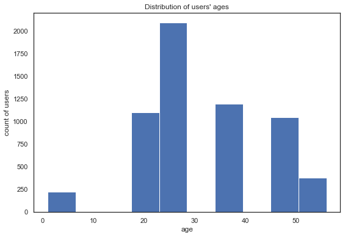

```python
# Visualization
# Graph on the user age distribution
plt.figure(figsize=(9, 6))
df_users.Age.plot.hist()
plt.title("Distribution of users' ages")
plt.ylabel('count of users')
plt.xlabel('age');
```

we can see the distribution of the users age are not continous

```python
# Average rating for each movie
df_movie_ratings.columns
```

```
Index(['movieId', 'title', 'genres', 'userId', 'rating', 'timestamp'], dtype='object')
```

```python
df_movie_ratings.groupby('title')['rating'].mean().head()
```

```
title
$1,000,000 Duck (1971)          3.03
'Night Mother (1986)            3.37
'Til There Was You (1997)       2.69
'burbs, The (1989)              2.91
...And Justice for All (1979)   3.71
Name: rating, dtype: float64
```

**Average rating**

```python
# sorting the ratings in the descending order of their average ratings:
df_movie_ratings.groupby('title')['rating'].mean().sort_values(ascending=False)[:20]
```

```
title
Gate of Heavenly Peace, The (1995)                                    5.00
Lured (1947)                                                          5.00
Ulysses (Ulisse) (1954)                                               5.00
Smashing Time (1967)                                                  5.00
Follow the Bitch (1998)                                               5.00
Song of Freedom (1936)                                                5.00
Bittersweet Motel (2000)                                              5.00
Baby, The (1973)                                                      5.00
One Little Indian (1973)                                              5.00
Schlafes Bruder (Brother of Sleep) (1995)                             5.00
I Am Cuba (Soy Cuba/Ya Kuba) (1964)                                   4.80
Lamerica (1994)                                                       4.75
Apple, The (Sib) (1998)                                               4.67
Sanjuro (1962)                                                        4.61
Seven Samurai (The Magnificent Seven) (Shichinin no samurai) (1954)   4.56
Shawshank Redemption, The (1994)                                      4.55
Godfather, The (1972)                                                 4.52
Close Shave, A (1995)                                                 4.52
Usual Suspects, The (1995)                                            4.52
Schindler's List (1993)                                               4.51
Name: rating, dtype: float64
```

**Sorting the movie ratings in descending order**

```python
# Get total number of ratings for a movie
df_movie_ratings.groupby('title')['rating'].count().sort_values(ascending=False)[:20]
```

```
title
American Beauty (1999)                                   3428
Star Wars: Episode IV - A New Hope (1977)                2991
Star Wars: Episode V - The Empire Strikes Back (1980)    2990
Star Wars: Episode VI - Return of the Jedi (1983)        2883
Jurassic Park (1993)                                     2672
Saving Private Ryan (1998)                               2653
Terminator 2: Judgment Day (1991)                        2649
Matrix, The (1999)                                       2590
Back to the Future (1985)                                2583
Silence of the Lambs, The (1991)                         2578
Men in Black (1997)                                      2538
Raiders of the Lost Ark (1981)                           2514
Fargo (1996)                                             2513
Sixth Sense, The (1999)                                  2459
Braveheart (1995)                                        2443
Shakespeare in Love (1998)                               2369
Princess Bride, The (1987)                               2318
Schindler's List (1993)                                  2304
L.A. Confidential (1997)                                 2288
Groundhog Day (1993)                                     2278
Name: rating, dtype: int64
```

**The average rating per movie and the number of ratings per movie are important attributes**

```python
ratings_mean_count = pd.DataFrame(data=df_movie_ratings.groupby('title')['rating'].mean())
ratings_mean_count['rating_counts'] = pd.DataFrame(df_movie_ratings.groupby('title')['rating'].count())
ratings_mean_count.columns
```

```
Index(['rating', 'rating_counts'], dtype='object')
```

```python
ratings_mean_count.reset_index(inplace=True)
ratings_mean_count.columns
```

```
Index(['title', 'rating', 'rating_counts'], dtype='object')
```

```python
# Lets see the rating mean count
ratings_mean_count.head()
```

|  | title | rating | rating_counts |
| --- | --- | --- | --- |
| 0 | $1,000,000 Duck (1971) | 3.03 | 37 |
| 1 | 'Night Mother (1986) | 3.37 | 70 |
| 2 | 'Til There Was You (1997) | 2.69 | 52 |
| 3 | 'burbs, The (1989) | 2.91 | 303 |
| 4 | ...And Justice for All (1979) | 3.71 | 199 |

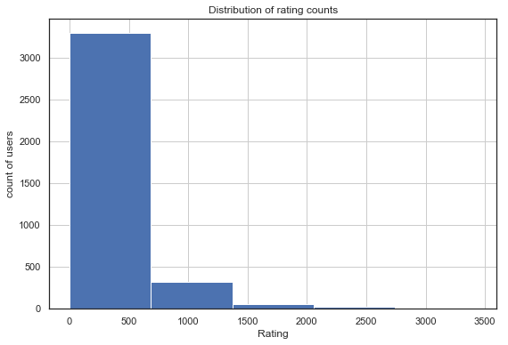

```python
# Display the graph for distribution of rating counts

plt.figure(figsize=(9, 6))
ratings_mean_count['rating_counts'].hist(bins=5)
plt.title("Distribution of rating counts")
plt.ylabel('count of users')
plt.xlabel('Rating');
```

**Here we are taking the Distribution of rating count of 5 results**

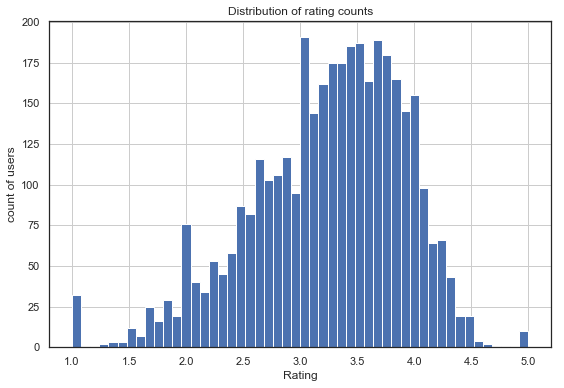

```python
plt.figure(figsize=(9, 6))
ratings_mean_count['rating'].hist(bins=50)
plt.title("Distribution of rating counts")
plt.ylabel('count of users')
plt.xlabel('Rating');
```

**Here we are taking the Distribution of rating count of 50 results**

**The normal distribution is weak with mean of 3.5**

**There are definitely ouliners here**

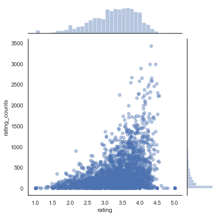

```python
# Movies with a higher number of rating have a high average rating

plt.figure(figsize=(10,6))
plt.rcParams['patch.force_edgecolor'] = True
sns.jointplot(x='rating', y='rating_counts', data=ratings_mean_count, alpha=0.4) ;
```

**The graph shows that, in general, movies with higher average ratings actually have more number of ratings, compared with movies that have lower average ratings.**

# **Find and visualize the user rating of the movie “Toy Story”**

```python
df_movie_ratings.columns
```

```
Index(['movieId', 'title', 'genres', 'userId', 'rating', 'timestamp'], dtype='object')
```

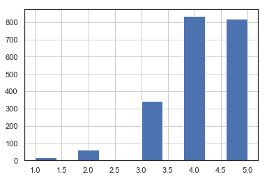

```python
df_movie_ratings[df_movie_ratings['title'] == 'Toy Story (1995)'].rating.hist();
```

**The ratings for the movie "Toy Story" is very high**

```python
# Find and visualize the viewership of the movie “Toy Story” by age group
labels = ['0-9',
          '10-19',
          '20-29',
          '30-39',
          '40-49',
          '50-59',
          '60-69',
          '70-79']
df_movie_ratings_users['age_group'] = pd.cut(df_movie_ratings_users.Age, range(0, 81, 10), right=False, labels=labels)
#df_users_copy[['age', 'age_group']].drop_duplicates()[:10]
```

```python
df_movie_ratings_users.head()
```

|  | movieId | title | genres | userId | rating | timestamp | Gender | Age | Occupation | Zip-code | age_group |
| --- | --- | --- | --- | --- | --- | --- | --- | --- | --- | --- | --- |
| 0 | 1 | Toy Story (1995) | Animation\|Children's\|Comedy | 1 | 5 | 978824268 | F | 1 | 10 | 48067 | 0-9 |
| 1 | 48 | Pocahontas (1995) | Animation\|Children's\|Musical\|Romance | 1 | 5 | 978824351 | F | 1 | 10 | 48067 | 0-9 |
| 2 | 150 | Apollo 13 (1995) | Drama | 1 | 5 | 978301777 | F | 1 | 10 | 48067 | 0-9 |
| 3 | 260 | Star Wars: Episode IV - A New Hope (1977) | Action\|Adventure\|Fantasy\|Sci-Fi | 1 | 4 | 978300760 | F | 1 | 10 | 48067 | 0-9 |
| 4 | 527 | Schindler's List (1993) | Drama\|War | 1 | 5 | 978824195 | F | 1 | 10 | 48067 | 0-9 |

**First five rows of the dataset with the age group**

```python
df_movie_ratings_users.groupby('age_group').agg({'rating': [np.size, np.mean]})
```

| age_group | rating size | rating mean |
| --- | --- | --- |
| 0-9 | 27,211.00 | 3.55 |
| 10-19 | 183,536.00 | 3.51 |
| 20-29 | 395,556.00 | 3.55 |
| 30-39 | 199,003.00 | 3.62 |
| 40-49 | 83,633.00 | 3.64 |
| 50-59 | 111,270.00 | 3.73 |
| 60-69 | nan | nan |
| 70-79 | nan | nan |

**The mean of rating of the age group between 0-9 is 3.55, where as the mean of the age group between 50-59 is 3.73**

```python
# Find and visualize the top 25 movies by viewership rating
df_movie_ratings_users.groupby('title').size().sort_values(ascending=False)[:25]
```

```
title
American Beauty (1999)                                   3428
Star Wars: Episode IV - A New Hope (1977)                2991
Star Wars: Episode V - The Empire Strikes Back (1980)    2990
Star Wars: Episode VI - Return of the Jedi (1983)        2883
Jurassic Park (1993)                                     2672
Saving Private Ryan (1998)                               2653
Terminator 2: Judgment Day (1991)                        2649
Matrix, The (1999)                                       2590
Back to the Future (1985)                                2583
Silence of the Lambs, The (1991)                         2578
Men in Black (1997)                                      2538
Raiders of the Lost Ark (1981)                           2514
Fargo (1996)                                             2513
Sixth Sense, The (1999)                                  2459
Braveheart (1995)                                        2443
Shakespeare in Love (1998)                               2369
Princess Bride, The (1987)                               2318
Schindler's List (1993)                                  2304
L.A. Confidential (1997)                                 2288
Groundhog Day (1993)                                     2278
E.T. the Extra-Terrestrial (1982)                        2269
Star Wars: Episode I - The Phantom Menace (1999)         2250
Being John Malkovich (1999)                              2241
Shawshank Redemption, The (1994)                         2227
Godfather, The (1972)                                    2223
dtype: int64
```

**Above are the results for the top 25 movies by viewership ratings**

```python
# Find the rating for a particular user of user id = 2696
df_movie_ratings_users[df_movie_ratings_users['userId'] == 2696]
```

|  | movieId | title | genres | userId | rating | timestamp | Gender | Age | Occupation | Zip-code | age_group |
| --- | --- | --- | --- | --- | --- | --- | --- | --- | --- | --- | --- |
| 991035 | 350 | Client, The (1994) | Drama\|Mystery\|Thriller | 2696 | 3 | 973308886 | M | 25 | 7 | 24210 | 20-29 |
| 991036 | 800 | Lone Star (1996) | Drama\|Mystery | 2696 | 5 | 973308842 | M | 25 | 7 | 24210 | 20-29 |
| 991037 | 1092 | Basic Instinct (1992) | Mystery\|Thriller | 2696 | 4 | 973308886 | M | 25 | 7 | 24210 | 20-29 |
| 991038 | 1097 | E.T. the Extra-Terrestrial (1982) | Children's\|Drama\|Fantasy\|Sci-Fi | 2696 | 3 | 973308690 | M | 25 | 7 | 24210 | 20-29 |
| 991039 | 1258 | Shining, The (1980) | Horror | 2696 | 4 | 973308710 | M | 25 | 7 | 24210 | 20-29 |
| 991040 | 1270 | Back to the Future (1985) | Comedy\|Sci-Fi | 2696 | 2 | 973308676 | M | 25 | 7 | 24210 | 20-29 |
| 991041 | 1589 | Cop Land (1997) | Crime\|Drama\|Mystery | 2696 | 3 | 973308865 | M | 25 | 7 | 24210 | 20-29 |
| 991042 | 1617 | L.A. Confidential (1997) | Crime\|Film-Noir\|Mystery\|Thriller | 2696 | 4 | 973308842 | M | 25 | 7 | 24210 | 20-29 |
| 991043 | 1625 | Game, The (1997) | Mystery\|Thriller | 2696 | 4 | 973308842 | M | 25 | 7 | 24210 | 20-29 |
| 991044 | 1644 | I Know What You Did Last Summer (1997) | Horror\|Mystery\|Thriller | 2696 | 2 | 973308920 | M | 25 | 7 | 24210 | 20-29 |
| 991045 | 1645 | Devil's Advocate, The (1997) | Crime\|Horror\|Mystery\|Thriller | 2696 | 4 | 973308904 | M | 25 | 7 | 24210 | 20-29 |
| 991046 | 1711 | Midnight in the Garden of Good and Evil (1997) | Comedy\|Crime\|Drama\|Mystery | 2696 | 4 | 973308904 | M | 25 | 7 | 24210 | 20-29 |
| 991047 | 1783 | Palmetto (1998) | Film-Noir\|Mystery\|Thriller | 2696 | 4 | 973308865 | M | 25 | 7 | 24210 | 20-29 |
| 991048 | 1805 | Wild Things (1998) | Crime\|Drama\|Mystery\|Thriller | 2696 | 4 | 973308886 | M | 25 | 7 | 24210 | 20-29 |
| 991049 | 1892 | Perfect Murder, A (1998) | Mystery\|Thriller | 2696 | 4 | 973308904 | M | 25 | 7 | 24210 | 20-29 |
| 991050 | 2338 | I Still Know What You Did Last Summer (1998) | Horror\|Mystery\|Thriller | 2696 | 2 | 973308920 | M | 25 | 7 | 24210 | 20-29 |
| 991051 | 2389 | Psycho (1998) | Crime\|Horror\|Thriller | 2696 | 4 | 973308710 | M | 25 | 7 | 24210 | 20-29 |
| 991052 | 2713 | Lake Placid (1999) | Horror\|Thriller | 2696 | 1 | 973308710 | M | 25 | 7 | 24210 | 20-29 |
| 991053 | 3176 | Talented Mr. Ripley, The (1999) | Drama\|Mystery\|Thriller | 2696 | 4 | 973308865 | M | 25 | 7 | 24210 | 20-29 |
| 991054 | 3386 | JFK (1991) | Drama\|Mystery | 2696 | 1 | 973308842 | M | 25 | 7 | 24210 | 20-29 |

**Above is the rating for a particular user of user id = 2696**

**Perform machine learning on first 500 extracted records • Use the following features:**

-movie id

-age

-occupation Use rating as label

-Create train and test data set and perform the following:

-Create a histogram for movie, age, and occupation

```python
# import the ML algorithm
from sklearn.neighbors import KNeighborsClassifier
from sklearn.linear_model import LinearRegression
from sklearn.linear_model import LogisticRegression
from sklearn.naive_bayes import GaussianNB
from sklearn.naive_bayes import MultinomialNB
from sklearn.tree import DecisionTreeClassifier
from sklearn.ensemble import RandomForestClassifier

# import libraries for model validation
from sklearn.model_selection import StratifiedKFold
from sklearn.model_selection import KFold
from sklearn.model_selection import cross_val_score
from sklearn.model_selection import train_test_split
from sklearn.model_selection import LeaveOneOut

# import libraries for metrics and reporting
from sklearn.metrics import confusion_matrix
from sklearn.metrics import classification_report
from sklearn.metrics import accuracy_score
from sklearn.metrics import precision_score
from sklearn.metrics import recall_score
from sklearn.metrics import f1_score
from sklearn import metrics
from sklearn.metrics import classification_report
from sklearn.metrics import roc_curve, auc
```

```python
df_movie_ratings_users.shape
```

```
(1000209, 11)
```

```python
feature_cols = ['movieId',
                'Age',
                'Occupation']

response_col = ['rating']
```

```python
# get the unique rating types
df_movie_ratings_users.rating.unique()
```

```
array([5, 4, 3, 2, 1], dtype=int64)
```

```python
# class balance
df_movie_ratings_users.rating.value_counts()
```

```
4    348971
3    261197
5    226310
2    107557
1     56174
Name: rating, dtype: int64
```

```python
df_movie_ratings_users.describe
```

[output not shown]

[output cut: 175 more lines]

```python
# extract 500 random rows from the df
df_movie_ratings_users_extract = df_movie_ratings_users.sample(n=500, random_state=0)
```

```python
X = df_movie_ratings_users_extract[feature_cols].values
y = df_movie_ratings_users_extract[response_col].values.ravel()
```

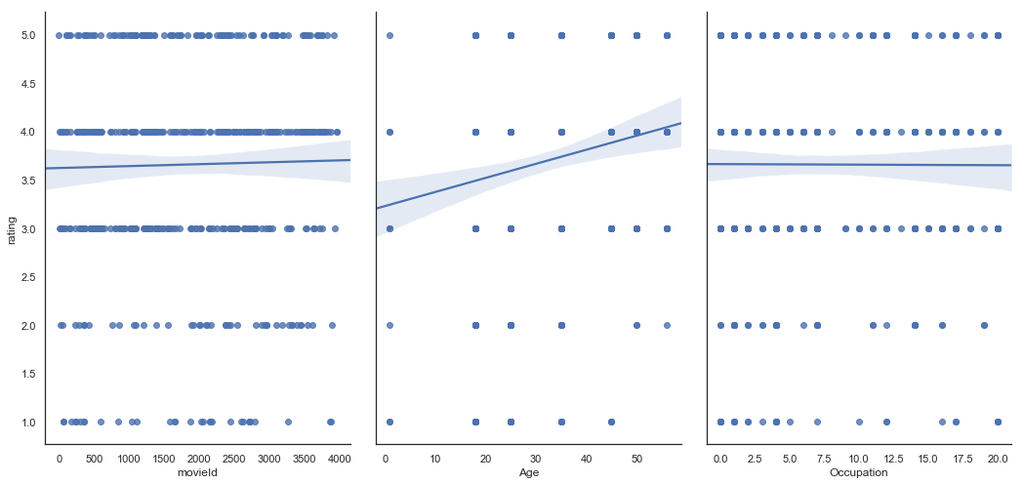

```python
sns.pairplot(df_movie_ratings_users_extract,
             x_vars=['movieId','Age','Occupation'],
             y_vars='rating',
             size=7,
             aspect=0.7,
             kind='reg')
```

```python
# Splitting X and y into training and testing sets
from sklearn.model_selection import train_test_split
X_train, X_test, y_train, y_test = train_test_split(X, y, random_state=1, test_size=0.3)
```

```python
# default split is 75% for training and 25% for testing
print(X_train.shape)
print(y_train.shape)
print(X_test.shape)
print(y_test.shape)
```

```
(350, 3)
(350,)
(150, 3)
(150,)
```

```python
# Using the linear regression model for this analysis
linreg = LinearRegression()

# fit the model to the training data (learn the coefficients)
linreg.fit(X_train, y_train)

# fit the model to the training data (learn the coefficients)
#linreg_sm = smdl.OLS(y_train, X_train).fit()
```

```
LinearRegression(copy_X=True, fit_intercept=True, n_jobs=None,
         normalize=False)
```

```python
# create a Python list of feature names
feature_cols = ['movieId', 'Age', 'Occupation']

# use the list to select a subset of the original DataFrame
X = df_movie_ratings_users_extract[feature_cols]

# select a Series from the DataFrame
y = df_movie_ratings_users_extract['rating']
```

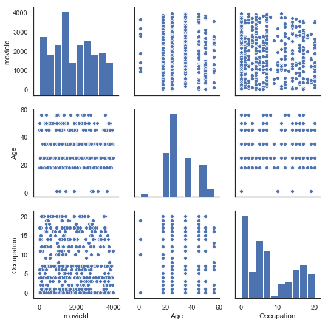

```python
sns.pairplot( X);
```

```python
y_pred = linreg.predict(X_test)
```

```python
y_pred
```

```
array([3.5895793 , 3.42309099, 4.00499691, 3.5621929 , 3.64973502,
       3.52321039, 3.72622529, 3.70702826, 3.62503149, 3.80116082,
       3.60653728, 3.74919798, 3.56837547, 3.73851056, 3.50263134,
       3.9661594 , 3.59475321, 3.52876614, 3.78659887, 3.4679587 ,
       3.61058355, 3.62348788, 3.7048536 , 3.78052716, 3.87399442,
       3.63566191, 3.74340537, 3.49882894, 4.03522207, 3.64098468,
       3.55380263, 3.72013422, 3.57545657, 4.0265291 , 3.73790976,
       3.53588875, 3.60739284, 3.61305631, 3.95077977, 3.54277175,
       3.53528905, 3.71913754, 3.63290303, 3.91230824, 3.52114032,
       4.03276993, 3.52504859, 3.61641453, 3.61833261, 3.88730771,
       3.60596359, 3.23765425, 3.5176825 , 3.95099375, 3.48142751,
       3.73498265, 3.96477166, 3.64096532, 3.59306387, 3.56852155,
       3.6156547 , 4.10316611, 3.54271825, 3.72655401, 3.50513787,
       3.56714968, 3.56345004, 3.47686565, 3.53798632, 3.50815648,
       3.59907506, 3.97017178, 3.75883026, 3.74606851, 3.59730972,
       3.48464921, 3.55139461, 3.53082958, 3.73018818, 3.53335659,
       3.6006447 , 3.58723253, 3.52906037, 3.6833524 , 3.47661367,
       3.77994223, 3.45954797, 3.93361071, 3.52608124, 3.50989894,
       3.75460801, 3.46756911, 3.54739908, 3.53421491, 3.54029823,
       3.62710655, 3.55294745, 4.03733864, 3.55484191, 3.94181097,
       4.09569965, 3.99988461, 3.59375967, 3.98556266, 3.60059931,
       3.95128773, 3.60931939, 3.9977457 , 3.54145612, 3.85194701,
       3.50300045, 3.65741158, 3.95098988, 3.62947123, 3.61846634,
       3.74201376, 3.5331961 , 3.63240221, 3.51261446, 3.52745938,
       4.08989966, 3.6864625 , 3.48111852, 3.63673181, 3.89978262,
       4.07619714, 3.53489522, 3.48034284, 3.61858145, 3.53889574,
       3.58815042, 3.52161439, 3.53974428, 3.66329218, 3.74594639,
       3.74828081, 3.19655444, 3.59327083, 3.62511173, 3.61346067,
       3.56719156, 3.52719339, 3.62853543, 3.63167652, 3.45631151,
       3.54482744, 3.4858261 , 3.47106143, 3.5871984 , 3.80155078])
```

```python
y_test
```

```
array([5, 2, 5, 4, 3, 4, 5, 3, 5, 1, 3, 4, 5, 4, 3, 3, 5, 4, 3, 4, 4, 3,
       5, 1, 4, 5, 5, 5, 5, 3, 2, 5, 4, 5, 3, 4, 5, 5, 3, 2, 4, 4, 5, 1,
       3, 3, 4, 5, 3, 4, 4, 5, 5, 4, 3, 3, 5, 4, 3, 4, 4, 3, 1, 3, 1, 2,
       5, 1, 1, 4, 3, 4, 5, 4, 4, 2, 3, 4, 5, 4, 4, 4, 3, 4, 3, 3, 4, 3,
       2, 4, 3, 4, 1, 3, 4, 3, 3, 3, 3, 3, 5, 4, 4, 5, 5, 5, 4, 2, 5, 5,
       4, 1, 5, 2, 2, 2, 4, 5, 5, 4, 5, 3, 3, 4, 4, 3, 1, 5, 3, 5, 4, 4,
       4, 1, 5, 4, 3, 3, 5, 3, 2, 3, 4, 4, 5, 4, 2, 5, 5, 5], dtype=int64)
```

```python
linreg.coef_
```

```
array([-2.67476021e-05,  1.55189830e-02, -3.85552792e-03])
```

```python
feature_cols
```

```
['movieId', 'Age', 'Occupation']
```

```python
list(zip(feature_cols, linreg.coef_))
```

```
[('movieId', -2.6747602078874993e-05),
 ('Age', 0.01551898298519422),
 ('Occupation', -0.00385552792355653)]
```

```python
linreg.intercept_
```

```
3.2851913460226845
```

**We have used the features movieId, age and Occupation using rating as the label**

[figure not shown]

```python
# Create a histogram for movieId, age and occupation

# This graph is for the movieId and rating
df_movie_ratings_users_extract.Age.plot.hist(bins=25)
plt.title("Movie & Rating")
plt.ylabel('MovieID')
plt.xlabel('Ratings')
```

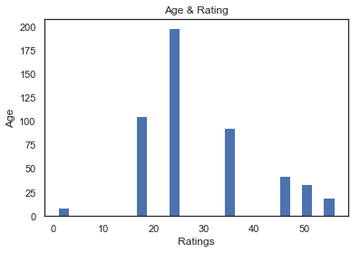

```python
# This is for the Age and rating
df_movie_ratings_users_extract.Age.plot.hist(bins=25)
plt.title("Age & Rating")
plt.ylabel('Age')
plt.xlabel('Ratings')
```

[figure not shown]

```python
# This graph is for the Occupation and rating
df_movie_ratings_users_extract.Age.plot.hist(bins=25)
plt.title("Occupation & Rating")
plt.ylabel('Occupation')
plt.xlabel('Ratings')
```